# R Notebook

```r
library(tidyverse)
library(broom)
library(nycflights13)
```

## Using the airports dataframe, display the names of New York City’s three major airports. They

have airport codes EWR, JFK, LGA. ## A Filtered the airport data to include the codes of EWR, JFK and LGA.

```r
airports %>% filter(faa == "EWR" | faa == "JFK" | faa == "LGA" )
```

| faa | name | lat | lon | alt | tz | dst | tzone |
| --- | --- | --- | --- | --- | --- | --- | --- |
| EWR | Newark Liberty Intl | 40.69250 | -74.16867 | 18 | -5 | A | America/New_York |
| JFK | John F Kennedy Intl | 40.63975 | -73.77893 | 13 | -5 | A | America/New_York |
| LGA | La Guardia | 40.77725 | -73.87261 | 22 | -5 | A | America/New_York |

```r
NA
NA
```

## We count how many flights have left the origin destination

```r
flights %>%
  count(origin)
```

| origin | n |
| --- | --- |
| EWR | 120835 |
| JFK | 111279 |
| LGA | 104662 |

```r
NA
NA
```

We have 120835, 111279 and 104662 for EWR, JFK and LGA respectively as the number of flights that left the origin destination

## C

We get the airport data and left join it so we can get the name of the airport and the destination as well as the names. THen we can count the number of time each place had a flight going towards using the count(name) function.

```r
flights %>%
  left_join(airports, by = c("dest" = "faa")) %>%
  select(dest, name) %>%
  count(name) %>%
  arrange(desc(n)) %>%
  slice(1:5)
```

| name | n |
| --- | --- |
| Chicago Ohare Intl | 17283 |
| Hartsfield Jackson Atlanta Intl | 17215 |
| Los Angeles Intl | 16174 |
| General Edward Lawrence Logan Intl | 15508 |
| Orlando Intl | 14082 |

OUr data shows 17283, 17215, 16174, 15508 and 14082 for Chicago Ohare Intl  
Hartsfield Jackson Atlanta Intl, Los Angeles Intl, General Edward Lawrence Logan Intl  
and Orlando Intl

## D

We create a dataframe which has for every flight its departure delay and the number of miles of visbility at it scheduled departure time at the airport

```r
departvisdelay <-
  flights %>%
  left_join(weather, by = c("origin" , "time_hour" )) %>%
  select(visib, dep_delay )
departvisdelay
```

| visib | dep_delay |
| --- | --- |
| 10 | 2 |
| 10 | 4 |
| 10 | 2 |
| 10 | -1 |
| 10 | -6 |
| 10 | -4 |
| 10 | -5 |
| 10 | -3 |
| 10 | -3 |
| 10 | -2 |

[output cut: 990 more lines]

##E We use a scatterplot since there are two quantitative variables

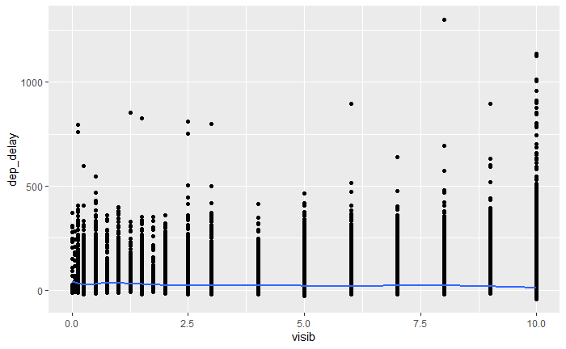

```r
ggplot(departvisdelay, aes(x = visib, y = dep_delay)) + geom_point() +geom_smooth(se = FALSE)
```

This scatter plot is extremly hard to infer a relationship from therefore we fix this

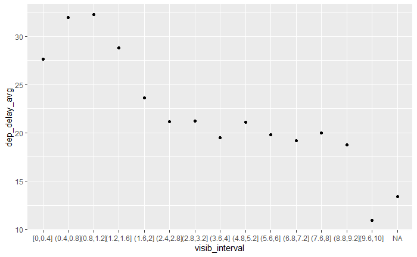

```r
departvisdelay %>%
  mutate(visib_interval = cut_interval(visib, n = 25)) %>%
  group_by(visib_interval) %>%
  summarise(dep_delay_avg = mean(dep_delay, na.rm = TRUE)) %>%
  ggplot(aes(x=visib_interval, y = dep_delay_avg)) +
  geom_point() + geom_smooth(se = FALSE)
```

```r
NA
```

We chunk up the the departure delay and visibility intervals into averages so it is easier to observe and notice changes. A standard graph as shown above is very messy and is hard to make an inference from or we would be making an observation out of something meaningless. This averaged graph shows a negative correlation relationship between visibility and departure delay. When the visbility is lower than 2.5 we do see an increase in departure delay All this indicates is that when the miles of visibility is low there are more departure delay than when the miles of visibility is high.